# WQS Test of Selection

Timothy M. Beissinger

17 September, 2016

Data from Lorenz, 2015 (G3) will be re-visited to test the hypothesis that the reason selection mapping and GWAS yielded no results, despite moderate to high heritabilities and phenotypic change, was because the selected traits were highly quantitative. To do this, allelic effects estimates from GWAS will be imported and allele frequency change from cycle 2 to cycle 5 will be computed. Then, the sum of frequency change multiplied by effect size will be computed. If GWAS effects and frequency changes are related, this sum should be non-zero and in the direction that the trait was selected. A permutation test will be conducted to test for significance.

### Data loading and prep

First we read in the Genotypes and phenotypes. There are not many markers here, and the reason why not is not explained in the paper… Something to ask Aaron about.

```r
### genos
setwd("/home/beissinger/Documents/ComplexSelection/Maize")
wqsGeno <- read.csv('../../WQS/DATA/genoWQS_randImp.csv',header=T,stringsAsFactors=F)
```

Now we’ll import the map.

```r
wqsMap <- read.csv('../../WQS/DATA/wqsMap_randImp.csv',stringsAsFactors=F)
```

Gapit cannot work with non-integer chromosomes. Remove those labeled “0”

```r
remMap <- which(wqsMap$Chromosome == 0)
remGeno <- remMap+1

wqsGeno<-wqsGeno[,-remGeno]
wqsMap<-wqsMap[-remMap,]
```

Now split individuals into different data frames according to their cycle

```r
names(wqsGeno)[1] <- "Taxa"
CycleIndicator <- as.numeric(unlist(strsplit(wqsGeno$Taxa,split="_C"))[seq(2,2*nrow(wqsGeno),2)])

Cycle0 <- wqsGeno[which(CycleIndicator == 0),]
Cycle1 <- wqsGeno[which(CycleIndicator == 1),]
Cycle2 <- wqsGeno[which(CycleIndicator == 2),]
Cycle3 <- wqsGeno[which(CycleIndicator == 3),]
Cycle4 <- wqsGeno[which(CycleIndicator == 4),]
Cycle5 <- wqsGeno[which(CycleIndicator == 5),]
CycleList <- list(Cycle0,Cycle1,Cycle2,Cycle3,Cycle4,Cycle5)
```

### Analysis

The next step is to calculate the allele frequency at each cycle.

```r
frequencies<-matrix(nrow=ncol(wqsGeno)-1,ncol=6)
for(i in 1:6){
frequencies[,i] <- colMeans(CycleList[[i]][,-1],na.rm=T)/2
}
frequencies <- as.data.frame(frequencies)
names(frequencies) <- c("Cycle0","Cycle1","Cycle2","Cycle3","Cycle4","Cycle5")
```

Now compute allele frequency change from cycle 2 to 5 and make a histogram

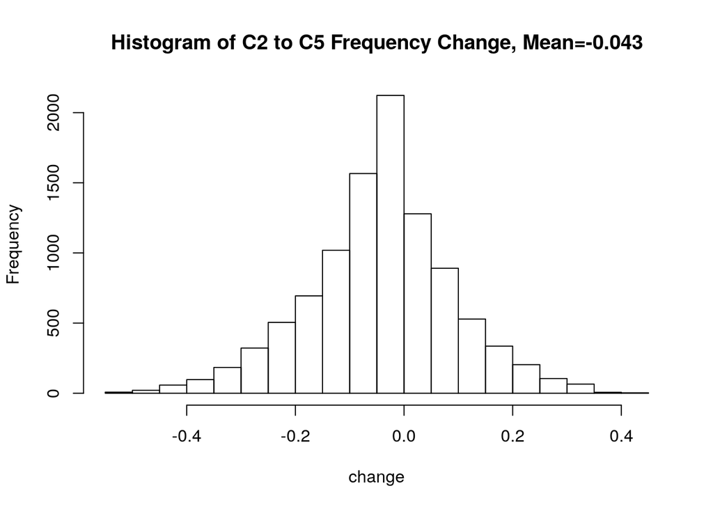

```r
change<-frequencies$Cycle5-frequencies$Cycle2
hist(change,main=paste("Histogram of C2 to C5 Frequency Change, Mean=",round(mean(change,na.rm=T),digits=3),sep=""))
```

Now load in phenotypes to enable calculating effects estimates.

```r
### phenos
setwd("/home/beissinger/Documents/WQS_Prediction/GWAS_effects/")
adf <- read.csv('../Previous_G3/wqsSupportingData/adfBlups.csv', head=TRUE,stringsAsFactors=F)
ndf <- read.csv('../Previous_G3/wqsSupportingData/ndfBlups.csv', head=TRUE,stringsAsFactors=F)
ivd <- read.csv('../Previous_G3/wqsSupportingData/ivdBlups.csv', head=TRUE,stringsAsFactors=F)
cp <- read.csv('../Previous_G3/wqsSupportingData/cpBlups.csv', head=TRUE,stringsAsFactors=F)
drymat <- read.csv('../Previous_G3/wqsSupportingData/dmBlups.csv', head=TRUE,stringsAsFactors=F)
starch <- read.csv('../Previous_G3/wqsSupportingData/starchBlups.csv', head=TRUE,stringsAsFactors=F)
yield <- read.csv('../Previous_G3/wqsSupportingData/yieldBlups.csv', head=TRUE,stringsAsFactors=F)

### restore working directory
setwd("/home/beissinger/Documents/ComplexSelection/Maize")
```

Now reformat genotypes file. Reorganize by coding to -1,0,1 and so that markers are columns, individuals are rows.

```r
geno<-wqsGeno
geno[,2:nrow(geno)] <- 1-geno[,2:nrow(geno)]
```

Now write a function to compute effects using the rrBLUP package

```r
library(rrBLUP)
rrblupFunction <- function(geno, pheno, map,main){
  ##drop "_CX" from rownames in geno
  names(geno)[1] <- "Taxa"
  geno$Taxa <- gsub('...$', '', wqsGeno$Taxa)

  ##remove inds without geno & pheno
    ndx <- match(geno[, 1], pheno[, 1])
    noPheno <- geno[, 1][which(is.na(ndx))]
    geno2 <- geno[-which(is.na(ndx)), ]
    ndx2 <- ndx[-which(is.na(ndx))]
    pheno2 <- pheno[ndx2, ]

    ##Calculate numbers for each cycle
    cycleIndNum <- vector(length=5)
    cycleIndNum[1] <- length(which(pheno2$Cycle=='C0'))
    cycleIndNum[2] <- length(which(pheno2$Cycle=='C1'))
    cycleIndNum[3] <- length(which(pheno2$Cycle=='C2'))
    cycleIndNum[4] <- length(which(pheno2$Cycle=='C3'))
    cycleIndNum[5] <- length(which(pheno2$Cycle=='C4'))
    yr <- as.character(pheno2$Cycle)
    yr <- as.factor(yr)
    pheno2 <- pheno2[, c(1, 2)]

    ##Remove individuals with missing phenoypte (these rows were in phenotype file as NA)
    pheno3<-pheno2[which(is.na(pheno2[,2])==F),]
    geno3<-geno2[which(is.na(pheno2[,2])==F),]
    print(paste("In total", nrow(geno3), "individuals."))

    #run rrBLUP


    #result <- mixed.solve(pheno2[,2], Z= as.matrix(geno2[,2:ncol(geno2)]),   K=NULL, SE=F, return.Hinv=FALSE,method="ML") # cycle NOT included as a covariate!

    #below is code to include cycle as a covariate
    fixedMat <- model.matrix(pheno2[,2]~yr) #model matrix for years

    result <- mixed.solve(pheno3[,2], Z= as.matrix(geno3[,2:ncol(geno3)]),X= model.matrix(pheno2[,2]~yr),   K=NULL, SE=F, return.Hinv=FALSE,method="ML") # cycle INCLUDED as a covariate!

    ##Plot predicted vs actual
    effects <- result$u
    effects.mat <- as.matrix(effects)
    predicted <- as.matrix(geno2[,2:ncol(geno2)]) %*% effects.mat
    predicted = predicted[,1] + result$beta[1]
    plot(pheno2[,2],predicted,xlab="True phenos",ylab="Predicted phenos",main=main)

    return(result$u)
}
```

Now run rrBLUP

```r
effects.ADF<-rrblupFunction(geno,adf,wqsMap,main="ADF")
```

```
## [1] "In total 136 individuals."
```

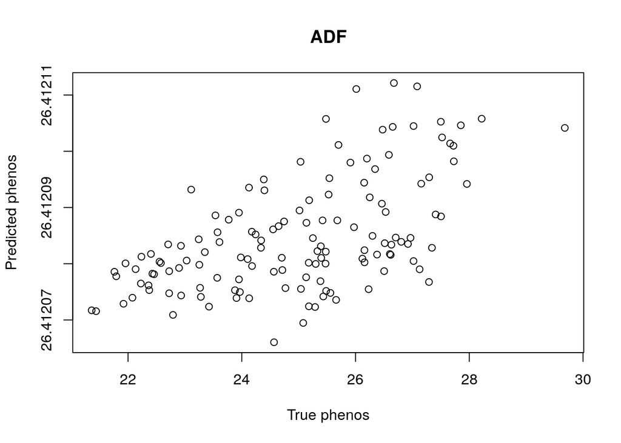

```r
effects.NDF<-rrblupFunction(geno,ndf,wqsMap,main="NDF")
```

```
## [1] "In total 136 individuals."
```

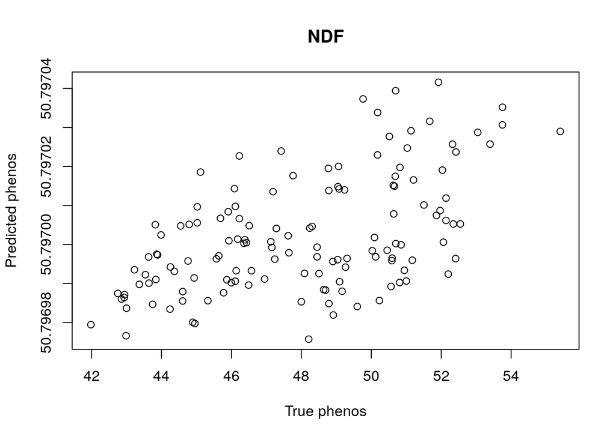

```r
effects.IVD<-rrblupFunction(geno,ivd,wqsMap,main="IVD")
```

```
## [1] "In total 136 individuals."
```

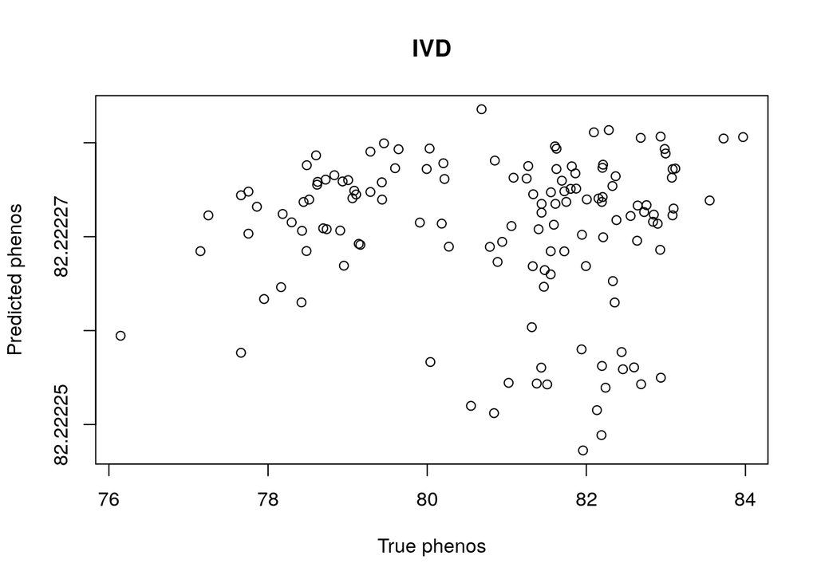

```r
effects.CP<-rrblupFunction(geno,cp,wqsMap,main="Crude Protein")
```

```
## [1] "In total 136 individuals."
```

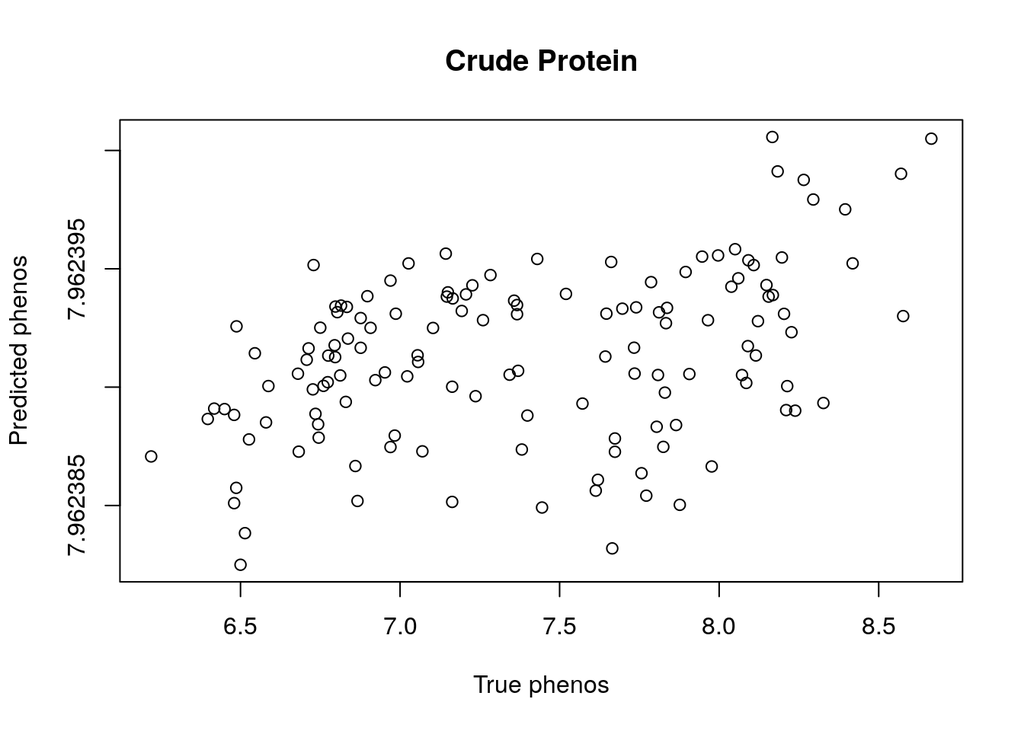

```r
effects.drymat<-rrblupFunction(geno,drymat,wqsMap,main="Dry matter")
```

```
## [1] "In total 277 individuals."
```

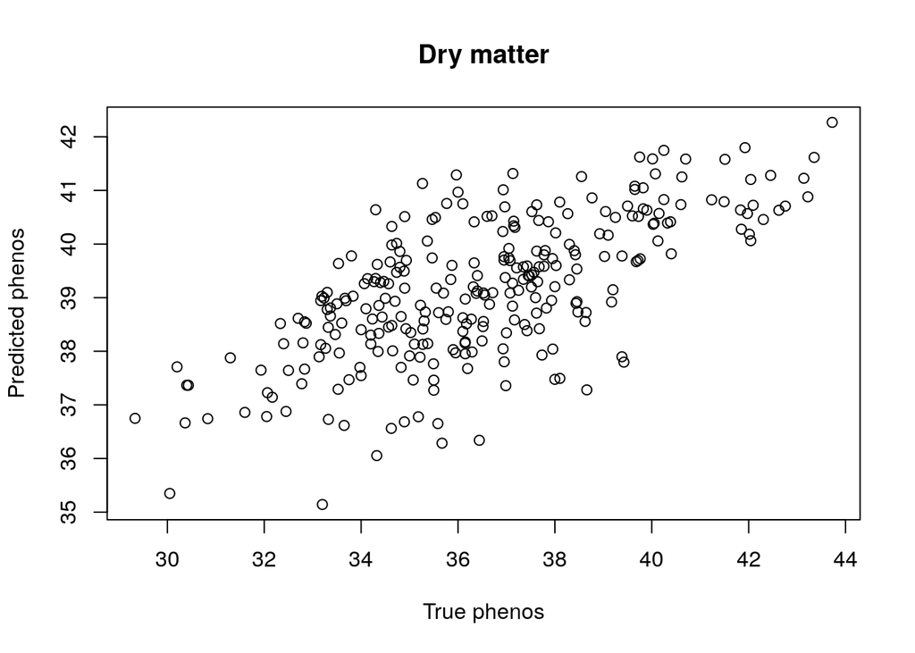

```r
effects.starch<-rrblupFunction(geno,starch,wqsMap,main="Starch")
```

```
## [1] "In total 136 individuals."
```

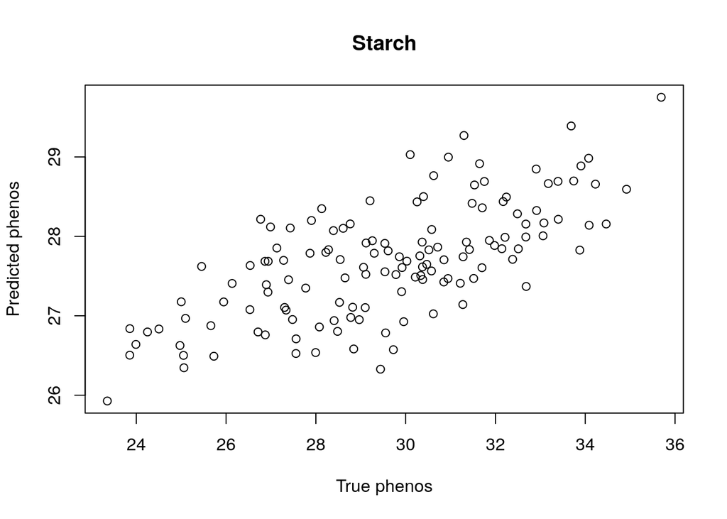

```r
effects.yield<-rrblupFunction(geno,yield,wqsMap,main="Yield")
```

```
## [1] "In total 215 individuals."
```

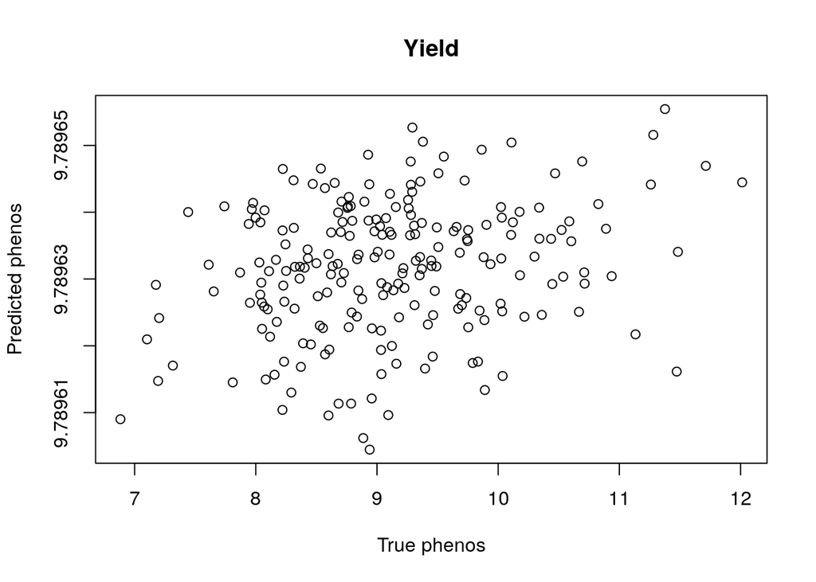

Now compute the sum of frequency*change

```r
adf_result <- sum(change*effects.ADF,na.rm=T)
ndf_result <- sum(change*effects.NDF,na.rm=T)
ivd_result <- sum(change*effects.IVD,na.rm=T)
cp_result <- sum(change*effects.CP,na.rm=T)
starch_result <- sum(change*effects.starch,na.rm=T)
yield_result <- sum(change*effects.yield,na.rm=T)
drymat_result <- sum(change*effects.drymat,na.rm=T)
```

Now do a quick permutation test. Are there reason that permuting SNPs is not a valid approach? (I can’t think of any at the moment)

```r
adf_test<-c(); ndf_test<-c(); ivd_test<-c(); cp_test<-c(); starch_test<-c(); yield_test<-c(); drymat_test<-c()
for(i in 1:10000){
  boot <- sample(change,length(change),replace=T)
  adf_test[i]<-sum(boot*effects.ADF,na.rm=T)
  ndf_test[i]<-sum(boot*effects.NDF,na.rm=T)
  ivd_test[i]<-sum(boot*effects.IVD,na.rm=T)
  cp_test[i]<-sum(boot*effects.CP,na.rm=T)
  starch_test[i]<-sum(boot*effects.starch,na.rm=T)
  yield_test[i]<-sum(boot*effects.yield,na.rm=T)
  drymat_test[i]<-sum(boot*effects.drymat,na.rm=T)
  }
```

### Results

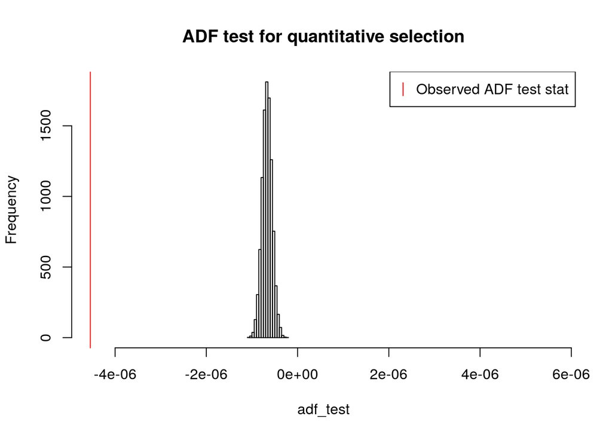

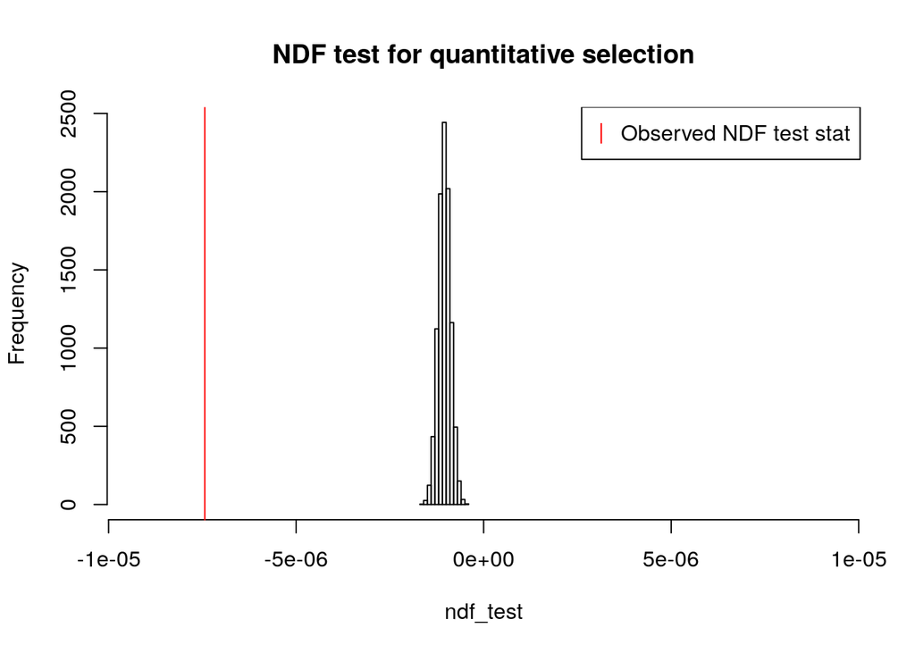

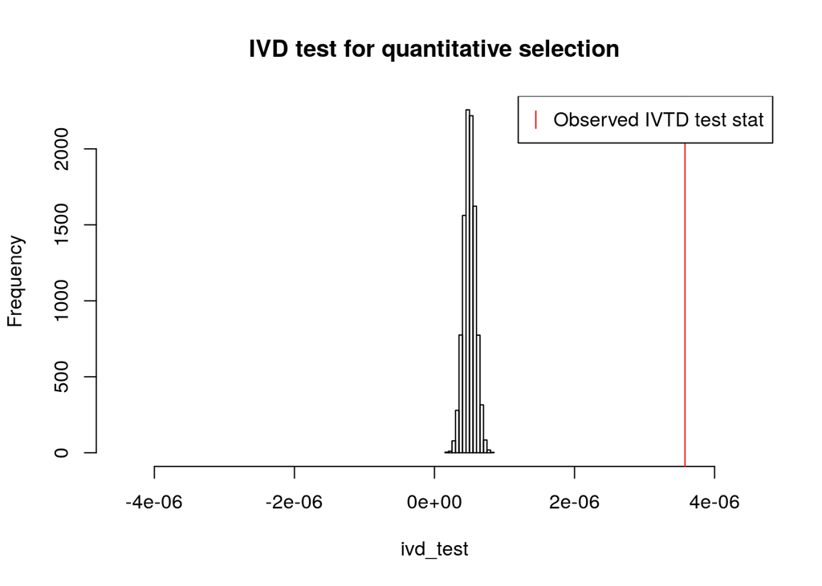

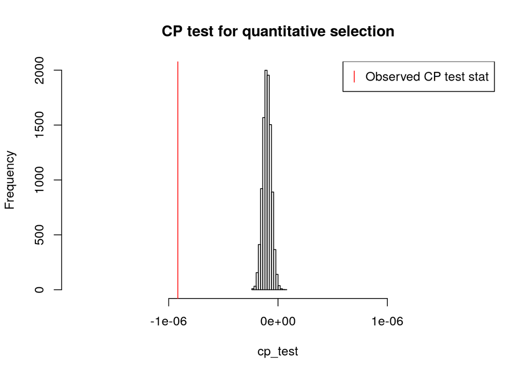

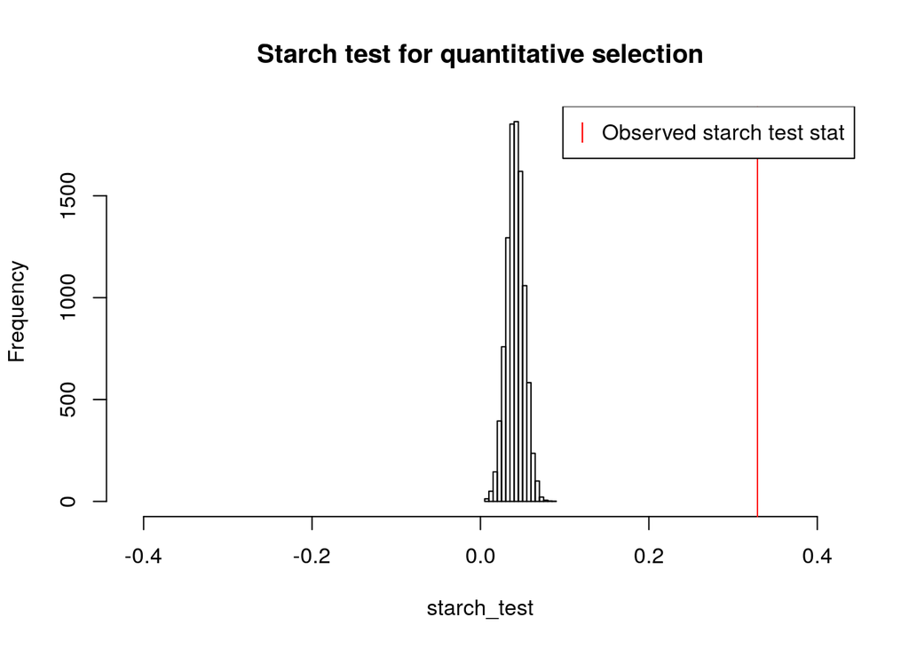

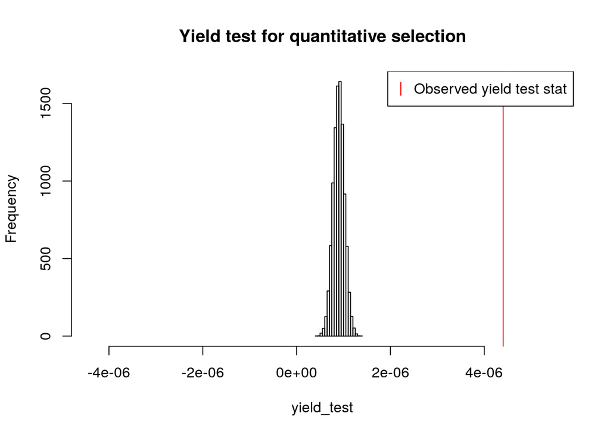

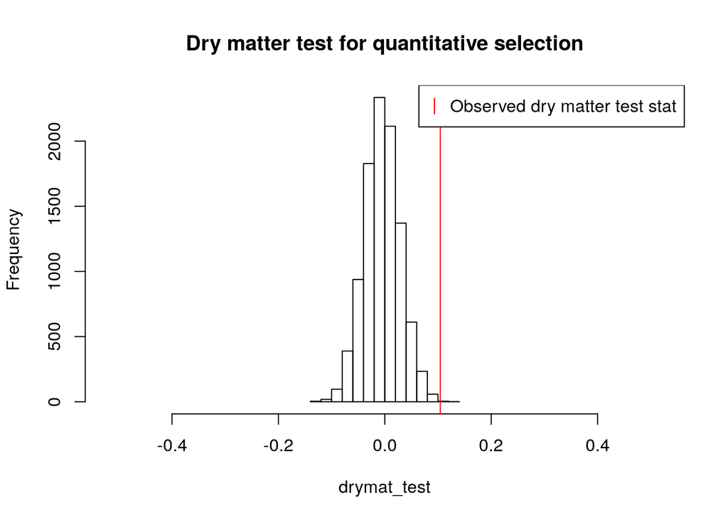

Test the correlation between trait allelic effects and frequency change.

```r
cor.test(change,effects.ADF,na.rm=T)
```

```
##
##  Pearson's product-moment correlation
##
## data:  change and effects.ADF
## t = -38.349, df = 10014, p-value < 2.2e-16
## alternative hypothesis: true correlation is not equal to 0
## 95 percent confidence interval:
##  -0.3748039 -0.3406491
## sample estimates:
##        cor
## -0.3578462
```

```r
cor.test(change,effects.NDF,na.rm=T)
```

```
##
##  Pearson's product-moment correlation
##
## data:  change and effects.NDF
## t = -43.401, df = 10014, p-value < 2.2e-16
## alternative hypothesis: true correlation is not equal to 0
## 95 percent confidence interval:
##  -0.4142490 -0.3812793
## sample estimates:
##        cor
## -0.3978926
```

```r
cor.test(change,effects.IVD,na.rm=T)
```

```
##
##  Pearson's product-moment correlation
##
## data:  change and effects.IVD
## t = 39.497, df = 10014, p-value < 2.2e-16
## alternative hypothesis: true correlation is not equal to 0
## 95 percent confidence interval:
##  0.3500633 0.3839545
## sample estimates:
##       cor
## 0.3671308
```

```r
cor.test(change,effects.CP,na.rm=T)
```

```
##
##  Pearson's product-moment correlation
##
## data:  change and effects.CP
## t = -21.971, df = 10014, p-value < 2.2e-16
## alternative hypothesis: true correlation is not equal to 0
## 95 percent confidence interval:
##  -0.2330532 -0.1956850
## sample estimates:
##        cor
## -0.2144476
```

```r
cor.test(change,effects.starch,na.rm=T)
```

```
##
##  Pearson's product-moment correlation
##
## data:  change and effects.starch
## t = 28.57, df = 10014, p-value < 2.2e-16
## alternative hypothesis: true correlation is not equal to 0
## 95 percent confidence interval:
##  0.2563254 0.2925432
## sample estimates:
##       cor
## 0.2745316
```

```r
cor.test(change,effects.yield,na.rm=T)
```

```
##
##  Pearson's product-moment correlation
##
## data:  change and effects.yield
## t = 30.993, df = 10014, p-value < 2.2e-16
## alternative hypothesis: true correlation is not equal to 0
## 95 percent confidence interval:
##  0.2778744 0.3136161
## sample estimates:
##       cor
## 0.2958488
```

```r
cor.test(change,effects.drymat,na.rm=T)
```

```
##
##  Pearson's product-moment correlation
##
## data:  change and effects.drymat
## t = 3.2973, df = 10014, p-value = 0.0009795
## alternative hypothesis: true correlation is not equal to 0
## 95 percent confidence interval:
##  0.01335643 0.05248278
## sample estimates:
##        cor
## 0.03293222
```

Now make pretty cumulative plots for each trait, like Jochen did with milk yield.

```r
cumulative <- data.frame(adf=rep(NA,nrow(wqsMap)),ndf=NA,ivd=NA,cp=NA,starch=NA,yield=NA,drymat=NA)
for(i in 1:nrow(cumulative)){
  if(i==1){
  cumulative$adf[i] <- change[i]*effects.ADF[i]
  cumulative$ndf[i] <- change[i]*effects.NDF[i]
  cumulative$ivd[i] <- change[i]*effects.IVD[i]
  cumulative$cp[i] <- change[i]*effects.CP[i]
  cumulative$starch[i] <- change[i]*effects.starch[i]
  cumulative$yield[i] <- change[i]*effects.yield[i]
  cumulative$drymat[i] <- change[i]*effects.drymat[i]
  }
  if(i>1){
  cumulative$adf[i] <- cumulative$adf[i-1]+change[i]*effects.ADF[i]
  cumulative$ndf[i] <- cumulative$ndf[i-1]+change[i]*effects.NDF[i]
  cumulative$ivd[i] <- cumulative$ivd[i-1]+change[i]*effects.IVD[i]
  cumulative$cp[i] <- cumulative$cp[i-1]+change[i]*effects.CP[i]
  cumulative$starch[i] <- cumulative$starch[i-1]+change[i]*effects.starch[i]
  cumulative$yield[i] <- cumulative$yield[i-1]+change[i]*effects.yield[i]
  cumulative$drymat[i] <- cumulative$drymat[i-1]+change[i]*effects.drymat[i]
  }
}

### Plots with thresholds
pdf("cumulativePlots_rrblup.pdf")
plot(cumulative$adf,col=wqsMap$Chromosome, main="Cumulative ADF freq*eff",xlab="Chromosome",xaxt="n",ylim=c(-1.5,1.5))
axis(1,c(-10000,700,2000,3300,4300,5300,6300,7000,8000,8700,9700,100000),lab=c(NA,1:10,NA))
abline(h=quantile(adf_test,c(0.025,0.975)),col="red")
legend("topright","c(x,y)","Significance thresholds",col="red",pch="=")

plot(cumulative$ndf,col=wqsMap$Chromosome, main="Cumulative NDF freq*eff",xlab="Chromosome",xaxt="n",ylim=c(-3,3))
axis(1,c(-10000,700,2000,3300,4300,5300,6300,7000,8000,8700,9700,100000),lab=c(NA,1:10,NA))
abline(h=quantile(ndf_test,c(0.025,0.975)),col="red")
legend("topright","c(x,y)","Significance thresholds",col="red",pch="=")

plot(cumulative$ivd,col=wqsMap$Chromosome, main="Cumulative IVTD freq*eff",xlab="Chromosome",xaxt="n",ylim=c(-1e-05,1e-05))
axis(1,c(-10000,700,2000,3300,4300,5300,6300,7000,8000,8700,9700,100000),lab=c(NA,1:10,NA))
abline(h=quantile(ivd_test,c(0.025,0.975)),col="red")
legend("topright","c(x,y)","Significance thresholds",col="red",pch="=")

plot(cumulative$cp,col=wqsMap$Chromosome, main="Cumulative CP freq*eff",xlab="Chromosome",xaxt="n",ylim=c(-1.5,1.5))
axis(1,c(-10000,700,2000,3300,4300,5300,6300,7000,8000,8700,9700,100000),lab=c(NA,1:10,NA))
abline(h=quantile(cp_test,c(0.025,0.975)),col="red")
legend("topright","c(x,y)","Significance thresholds",col="red",pch="=")

plot(cumulative$starch,col=wqsMap$Chromosome, main="Cumulative starch freq*eff",xlab="Chromosome",xaxt="n",ylim=c(-2,2))
axis(1,c(-10000,700,2000,3300,4300,5300,6300,7000,8000,8700,9700,100000),lab=c(NA,1:10,NA))
abline(h=quantile(starch_test,c(0.025,.975)),col="red")
legend("topright","c(x,y)","Significance thresholds",col="red",pch="=")

plot(cumulative$yield,col=wqsMap$Chromosome, main="Cumulative yield freq*eff",xlab="Chromosome",xaxt="n",ylim=c(-4e-06,4e-06))
axis(1,c(-10000,700,2000,3300,4300,5300,6300,7000,8000,8700,9700,100000),lab=c(NA,1:10,NA))
abline(h=quantile(yield_test,c(0.025,0.975)),col="red")
legend("topright","c(x,y)","Significance thresholds",col="red",pch="=")

plot(cumulative$drymat,col=wqsMap$Chromosome, main="Cumulative dry matter freq*eff",xlab="Chromosome",xaxt="n",ylim=c(-2,2))
axis(1,c(-10000,700,2000,3300,4300,5300,6300,7000,8000,8700,9700,100000),lab=c(NA,1:10,NA))
abline(h=quantile(drymat_test,c(0.025,0.975)),col="red")
legend("topright","c(x,y)","Significance thresholds",col="red",pch="=")
dev.off()
```